# Homework 5

Mary Kate Campbell

02/05/2020

# Load packages

Save any data frames generated to curated_data directory, save all plots to figures directory. Based on assumptions, clearly state which statistical test will be used and why. Include any statistics (p- or R-values) as comments after the tests.

# Question 1

Use the SCFA wide dataframe from Lab 5. Check assumptions, conduct statistical tests, make a plot, to answer the question, “Which supplement causes the greatest increase in acetate concentrations?”

```r
q1_df <- read_delim(file = "raw_data/scfa_wide.txt",
                        delim = "\t", escape_double = FALSE,
                        trim_ws = TRUE, na=c("NA"),
                        col_names = TRUE,
                        col_types = cols(participant_id = col_character(),
                                         semester = col_character(),
                                         supplement_consumed = col_character(),
                                         quantity_compliant = col_character(),
                                         frequency = col_character(),
                                         acetate_delta = col_double(),
                                         butyrate_delta = col_double(),
                                         propionate_delta = col_double())) %>%
  filter(semester != "Winter2015",
         quantity_compliant != "no")
```

```r
acetate_df <- q1_df %>%
  select(-starts_with("butyrate"), -starts_with("propionate"))
#check sample size
acetate_df %>%
  group_by(supplement_consumed) %>%
  summarise(sample_size = n())
```

```
## # A tibble: 12 x 2
##    supplement_consumed sample_size
##    <chr>                     <int>
##  1 Accessible                   31
##  2 Arabino                      20
##  3 BRMPS                       130
##  4 BRMPS+Accessible             16
##  5 HiMaize                      40
##  6 HiMaize+BRMPS                21
##  7 Inulin                       45
##  8 LOODAT                       16
##  9 none                         22
## 10 Psyllium                     16
## 11 Psyllium+BRMPS               15
## 12 transition_HiMaize           27
```

```r
#check variances
bartlett.test(acetate_delta ~ supplement_consumed, data = acetate_df)
```

```
##
##  Bartlett test of homogeneity of variances
##
## data:  acetate_delta by supplement_consumed
## Bartlett's K-squared = 22.886, df = 11, p-value = 0.01834
```

```r
# Bartlett test gave us a p-value of 0.01834, this is smaller than 0.05. So we cannot use ANOVA)
```

```r
kruskal.test(supplement_consumed ~ acetate_delta, acetate_df)
```

```
##
##  Kruskal-Wallis rank sum test
##
## data:  supplement_consumed by acetate_delta
## Kruskal-Wallis chi-squared = 390.3, df = 391, p-value = 0.5005
```

```r
#our p-value from the kruskall-wallis test was 0.5005. Since this p-value is greater than 0.05 we cannot determine whether one group has a larger effect on acetate concentration
```

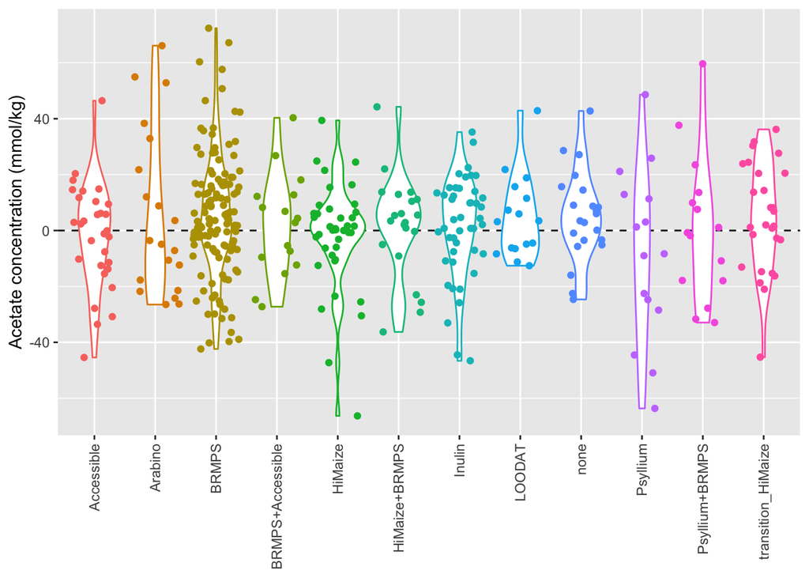

```r
acetate_plot <- acetate_df %>%
  ggplot(aes(x = supplement_consumed,
             y = acetate_delta,
             color = supplement_consumed)) +
  geom_hline(yintercept = 0, linetype = "dashed") +
  geom_violin() +
  geom_jitter() +
  xlab(NULL) +
  ylab("Acetate concentration (mmol/kg)") +
  theme(legend.position = "none",
        axis.text.x = element_text(angle = 90, vjust = 0.5, hjust = 1))

acetate_plot
```

```r
save_plot(acetate_plot, ncol = 1, nrow = 1, filename = "HW-figures/acetate_plot.pdf")
```

What are your conclusions regarding the reseach question?

I conclude that we cannot determine which supplement is associated with the greatest increase in acetate concentration. We failed to meet the assumptions of the ANOVA test because our sample sizes were not all greater than 30 and our p-value from our bartless test for equal variances was 0.01834, which is less than 0.05. Therefore, our data was not normal so we have to use the Kruskall-Wallace test for non-normal data sets. After running the Kruskall-Wallace test we got a p-value of 0.5005 which is greater than our significance level of 0.05. Therefore, there is not statistical evidence to determine that one of the supplements has the greatest increase in acetate concentration.